# Week 10 / Day 3 / Review

# Load Libraries / Read Data

```r
library(tidyverse)
library(modelr)
library(GGally)
library(ggfortify)
library(skimr)
```

```r
kc_houses <- read_csv("data/kc_house_data.csv")
```

# Explore Data

We want to build an explanatory model for `price`, so lets look at its distribution. We can see from the below that it’s highly right skewed.

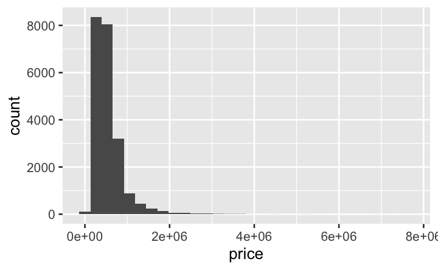

```r
ggplot(data = kc_houses, aes(x = price)) +
  geom_histogram()
```

## Feature Engineering

```r
kc_houses_trim <- kc_houses %>%
  select(-id, -date) %>%
  mutate(has_been_renovated = yr_renovated != 0,
         waterfront = as.logi(waterfront)) %>%
  select(-yr_renovated)
```

[output not shown]

Rather than running `ggpairs()` across all variables, try grouping these into variables you think are associated.

### Explore Group 1

Group 1: Size of House: bedrooms, bathrooms, sqft_living, sqft_lot, floors, sqft_above, sqft_above

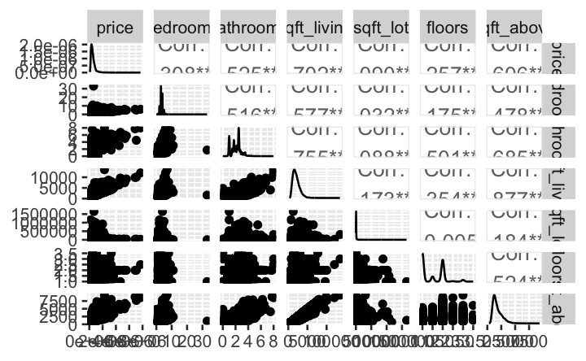

```r
kc_houses_trim %>%
  select(price, bedrooms, bathrooms, sqft_living, sqft_lot, floors, sqft_above, sqft_above) %>%
  ggpairs(progress = FALSE)
```

### Explore Group 2

Group 2: Location: waterfront, view, lat, long, zipcode

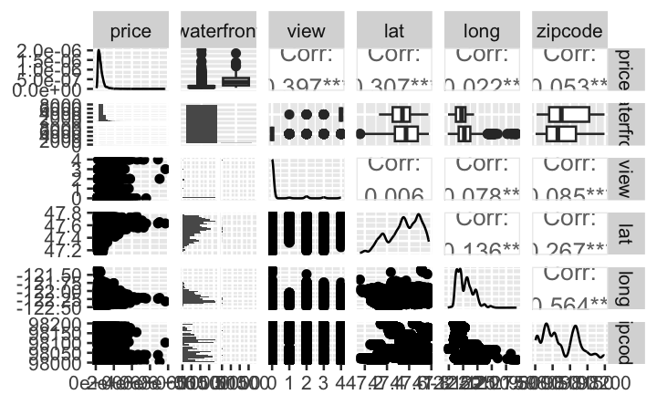

```r
kc_houses_trim %>%
  select(price, waterfront, view, lat, long, zipcode) %>%
  ggpairs(progress = FALSE)
```

### Explore Group 3

Group 3: Current State: has_been_renovated, condition, grade

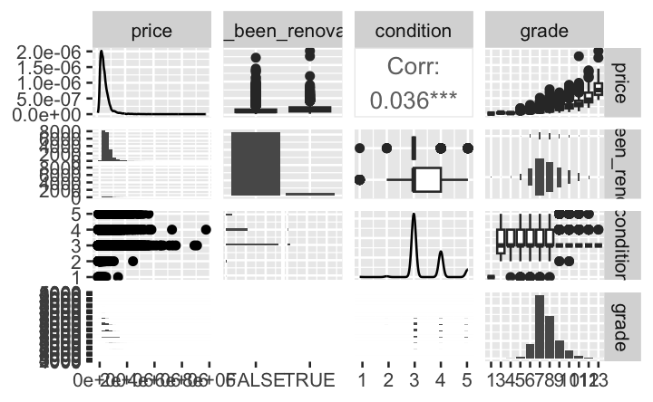

```r
kc_houses_trim %>%
  select(price, has_been_renovated, condition, grade) %>%
  ggpairs(progress = FALSE)
```

### Explore Group 4

Group 4: Age: yr_built

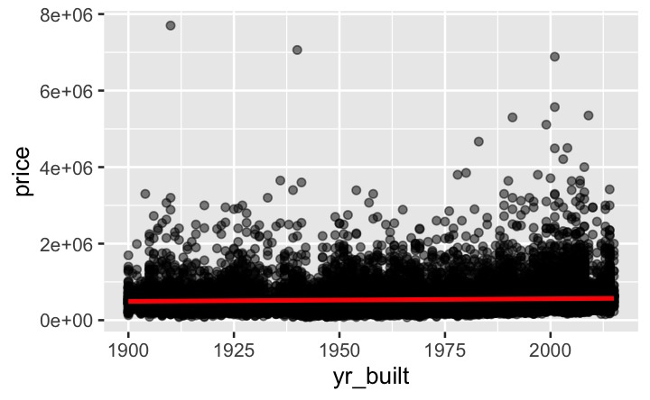

```r
ggplot(kc_houses_trim, aes(x = yr_built, y = price)) +
  geom_point(alpha = 0.5) +
  geom_smooth(method = "lm", colour = "red")
```

## Select Initial Predictor Candidates from Each Group

After exploration, the following look like to candidates:

- sqft_living
- lat or waterfront
- grade
- yr_build

## Check for Correlation & Aliases In Selected Initial Predictor Candidates

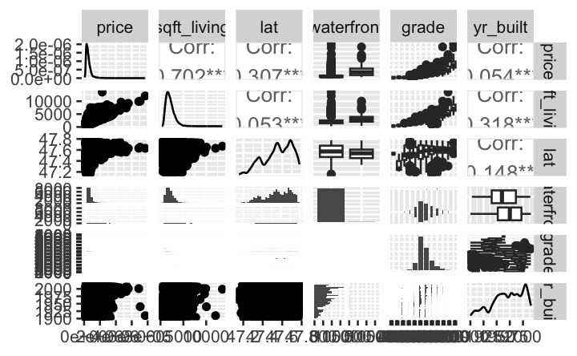

```r
kc_houses_trim %>%
  select(price, sqft_living, lat, waterfront, grade, yr_built) %>%
  ggpairs(progress = FALSE)
```

```r
alias(price, sqft_living, lat, watefront, grade, yr_built, data = kc_houses_trim)
```

```
Error in alias(price, sqft_living, lat, watefront, grade, yr_built, data = kc_houses_trim) :
  object 'price' not found
```

## Create Candidates Tibble

```r
kc_houses_candidates <- kc_houses_trim %>%
  select(price, sqft_living, lat, waterfront, grade, yr_built)
```

# Build Model

```r
model_1 <- lm(log(price) ~ sqft_living, data = kc_houses_candidates)
```

## Check Model Summary

```r
summary(model_1)
```

```
Call:
lm(formula = log(price) ~ sqft_living, data = kc_houses_candidates)

Residuals:
     Min       1Q   Median       3Q      Max
-2.97781 -0.28543  0.01472  0.26070  1.27628

Coefficients:
             Estimate Std. Error t value Pr(>|t|)
(Intercept) 1.222e+01  6.374e-03  1916.9   <2e-16 ***
sqft_living 3.987e-04  2.803e-06   142.2   <2e-16 ***
---
Signif. codes:  0 ‘***’ 0.001 ‘**’ 0.01 ‘*’ 0.05 ‘.’ 0.1 ‘ ’ 1

Residual standard error: 0.3785 on 21611 degrees of freedom
Multiple R-squared:  0.4835,    Adjusted R-squared:  0.4835
F-statistic: 2.023e+04 on 1 and 21611 DF,  p-value: < 2.2e-16
```

## Check Diagnostics

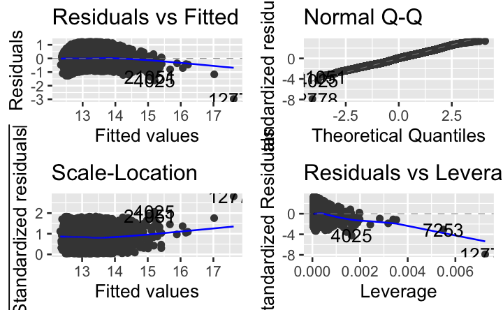

```r
autoplot(model_1)
```

# 2nd Predictor

## Add Residuals

Remember to remove predictors that are already in the model - `sqft_living` and `price`.

| lat | waterfront | grade | yr_built | resid |
| --- | --- | --- | --- | --- |
| 47.5112 | FALSE | 7 | 1955 | -0.3790029032 |
| 47.7210 | FALSE | 7 | 1951 | -0.0476288618 |
| 47.7379 | FALSE | 6 | 1933 | -0.4247868013 |
| 47.5208 | FALSE | 7 | 1965 | 0.3113221646 |
| 47.6168 | FALSE | 8 | 1987 | 0.2538077232 |
| 47.6561 | FALSE | 11 | 2001 | -0.3612189344 |
| 47.3097 | FALSE | 7 | 1995 | -0.4435394112 |
| 47.4095 | FALSE | 7 | 1963 | -0.0571401768 |
| 47.5123 | FALSE | 7 | 1960 | -0.5845746269 |
| 47.3684 | FALSE | 7 | 2003 | -0.2866874524 |

[output cut: 990 more lines]

## Check Remaining Predictor Candidates Against Residuals for Correlation

From the below we can see that there appears to be a strong correlation between `lat`, `waterfront` and `grade` and the residuals.

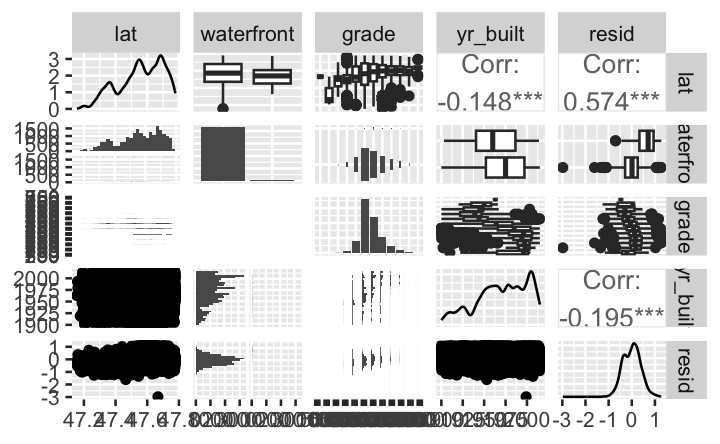

```r
kc_resid %>%
  ggpairs(progress = FALSE)
```

## Create 2nd Model

```r
model_2a <- lm(log(price) ~ sqft_living + lat, data = kc_houses_candidates)
```

## Check Model Summary

```r
summary(model_2a)
```

```
Call:
lm(formula = log(price) ~ sqft_living + lat, data = kc_houses_candidates)

Residuals:
     Min       1Q   Median       3Q      Max
-3.00396 -0.19459 -0.01122  0.18293  1.24316

Coefficients:
              Estimate Std. Error t value Pr(>|t|)
(Intercept) -6.256e+01  7.239e-01  -86.42   <2e-16 ***
sqft_living  3.863e-04  2.297e-06  168.17   <2e-16 ***
lat          1.573e+00  1.522e-02  103.31   <2e-16 ***
---
Signif. codes:  0 ‘***’ 0.001 ‘**’ 0.01 ‘*’ 0.05 ‘.’ 0.1 ‘ ’ 1

Residual standard error: 0.3097 on 21610 degrees of freedom
Multiple R-squared:  0.6542,    Adjusted R-squared:  0.6542
F-statistic: 2.045e+04 on 2 and 21610 DF,  p-value: < 2.2e-16
```

## Check Diagnostics

```r
autoplot(model_2a)
```

[output not shown]

Final Model: log(price) ~ sqft_living + lat

Interpretation: The price of a house in KC country can be explained by a combination of it’s size (sqft of the living space) and it’s latitude (Northerness).

Example: For a house at 1910 sqft (median sqft) located at latitude 47.56 (median lat), the predicted price would be $437884.3 (low estimate = 321261.3, high estimate = 596843.4).

as calculated below.

Step 1. outcome = b0 + b1 * 1st Predictor + b2 * 2nd Predictor

Step 2. log(price) = b0(intercept) + b1(coefficient) * 1st Predictor + b2(coefficient) * 2nd Predictor

Step 3. log(price) = b0(intercept) + b1(coefficient) * `sqft_living` + b2(coefficient) * `lat`

Step 4. log(price) = -62.56 + 3.863e-04 * `1910` + 1.573 * `47.56` = 12.98971

Step 5. price = e^12.98971 (exp 12.98971 ) = 437884.3

```r
exp(12.98971 + c(-0.3097, 0.3097))
```

```
[1] 321261.3 596843.4
```